# Stat542: Classification Tree

## Email Spam Data

```r
library(tree)
spam=read.table("spam.txt");
spam=data.frame(spam);
spam.name=read.table("spam_name.txt", as.is=TRUE);
for(i in 1:57) names(spam)[i]=as.character(spam.name[i,]);
names(spam)[58]="Y";
spam$Y=as.factor(spam$Y);

n=dim(spam)[1];
test.id = sample(1:n, round(n*0.2))
```

#### Fit a large classification tree on the Spam Data

```r
spam.tr=tree(Y~., spam[-test.id,], mindev=0.005, minsize=2); # Grow a BIG tree
#spam.tr
#summary(spam.tr)
```

Understand how the df and deviance are computed.

```r
myout=spam.tr$frame
leaf.nodes = myout[myout$var == "<leaf>",]
leaf.nodes
sum(leaf.nodes$n)
c(sum(leaf.nodes$n) - summary(spam.tr)$size, summary(spam.tr)$df)

myp = leaf.nodes[,6];
id = apply(myp, 1, min) > 0;
mydev = 2*sum(leaf.nodes$n[id]*(myp[id,1]*log(1/myp[id,1])+myp[id,2]*log(1/myp[id,2])))
# mydev should agree with the R output
c(mydev, summary(spam.tr)$dev)
```

[output not shown]

### Use CV to pick the best tree size.

Default: 10-fold CV based on deviance prunning.

```r
cv.spam1=cv.tree(spam.tr)
names(cv.spam1)
```

```
## [1] "size"   "dev"    "k"      "method"
```

```r
cv.spam1
```

```
## $size
##  [1] 25 24 23 22 21 18 17 16 15 14 13 12 11 10  9  8  7  6  5  4  3  2  1
##
## $dev
##  [1] 1983 1983 1983 1983 1983 1983 1983 1983 1983 1983 2031 2070 2074 2111
## [15] 2114 2294 2294 2423 2460 2693 3166 3763 4943
##
## $k
##  [1]    -Inf   25.90   26.01   26.82   31.54   31.97   33.07   33.12
##  [9]   33.83   44.39   52.23   56.54   58.96   66.88   70.14  101.78
## [17]  102.13  120.34  131.14  199.26  412.50  671.38 1236.93
##
## $method
## [1] "deviance"
##
## attr(,"class")
## [1] "prune"         "tree.sequence"
```

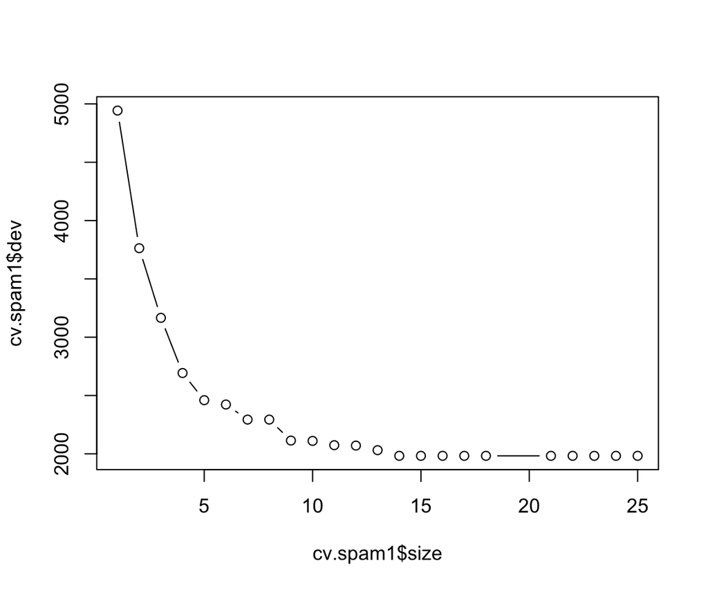

```r
plot(cv.spam1$size ,cv.spam1$dev ,type="b")
```

```r
cv.spam1$size[which.min(cv.spam1$dev)]
```

```
## [1] 25
```

Prune based on the misclassification rate, although it’s called `dev` in the R output.

```r
cv.spam2=cv.tree(spam.tr, FUN = prune.misclass)
par(mfrow=c(1,2))
plot(cv.spam2$size ,cv.spam2$dev ,type="b")
plot(cv.spam2$k ,cv.spam2$dev ,type="b")

cv.spam2$size[which.min(cv.spam2$dev)]
```

[output not shown]

#### Cut the tree to the desired size.

We can prune the tree using two different criteria: misclass and deviance. Sometimes the results are slightly different.

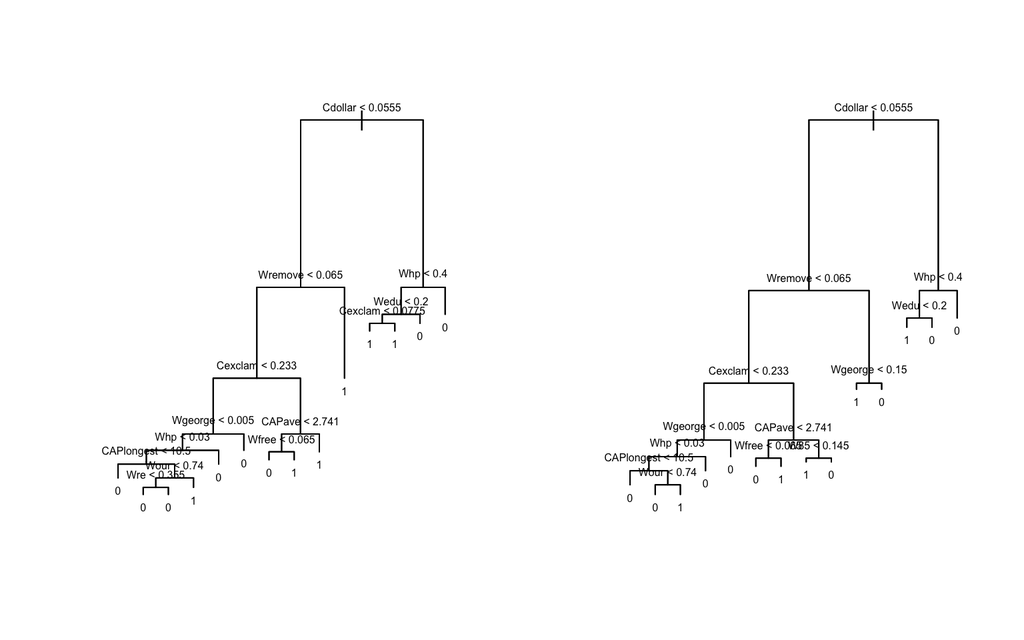

```r
bestsize=14;
spam.tr1=prune.tree(spam.tr, best=bestsize);
spam.tr2=prune.misclass(spam.tr, best=bestsize); # should be the same as:
#spam.tr2=prune.tree(spam.tr, method="misclass", best=bestsize);

par(mfrow=c(1,2));
plot(spam.tr1);
text(spam.tr1, cex=0.5);
plot(spam.tr2);
text(spam.tr2, cex=0.5);
```

### Prediction

- If type = `vector`: vector of predicted responses or, if the response is a factor, matrix of predicted class probabilities. This new object is obtained by dropping newdata down object. For factor predictors, if an observation contains a level not used to grow the tree, it is left at the deepest possible node and frame$yval or frame$yprob at that node is the prediction.
- If type = `tree`: an object of class “tree” is returned with new values for frame$n and frame$dev. If newdata does not contain a column for the response in the formula the value of frame$dev will be NA, and if some values in the response are missing, the some of the deviances will be NA.
- If type = `class`: for a classification tree, a factor of the predicted classes (that with highest posterior probability, with ties split randomly).
- If type = `where`: the nodes the cases reach.

> The training and testing misclassification errors are given below. It seems `prune.misclass` performs better if the performance is measured by 0/1 loss. But as mentioned before, it’s better to use Gini or deviance to grow a tree.

```r
train.pred1 = predict(spam.tr1, spam[-test.id,], type="class")
table(train.pred1, spam$Y[-test.id])
```

```
##
## train.pred1    0    1
##           0 2115  191
##           1  110 1265
```

```r
train.pred2 = predict(spam.tr2, spam[-test.id,], type="class")
table(train.pred2, spam$Y[-test.id])
```

```
##
## train.pred2    0    1
##           0 2130  191
##           1   95 1265
```

```r
test.pred1 = predict(spam.tr1, spam[test.id,], type="class")
table(test.pred1, spam$Y[test.id])
```

```
##
## test.pred1   0   1
##          0 529  55
##          1  34 302
```

```r
test.pred2 = predict(spam.tr2, spam[test.id,], type="class")
table(test.pred2, spam$Y[test.id])
```

```
##
## test.pred2   0   1
##          0 536  55
##          1  27 302
```